# Generalized linear models: count data

Author

Maciej Beręsewicz

# 1 Packages

**R**

```r
install.packages("MASS")
install.packages("AER")
install.packages("performance")
install.packages("marginaleffects")
install.packages("modelsummary")
install.packages("broom")
install.packages("topmodels", repos = "http://R-Forge.R-project.org")
install.packages("countreg",  repos = "http://R-Forge.R-project.org")
```

```r
library(MASS)
library(AER)
library(performance)
library(marginaleffects)
library(modelsummary)
library(broom)
library(boot)
```

**Python**

```bash
!pip install statsmodels
!pip install marginaleffects
```

```python
import numpy as np
import pandas as pd
import statsmodels.api as sm
import statsmodels.formula.api as smf
```

**Julia**

```julia
using Pkg
Pkg.add(["GLM", "CSV", "DataFrames", "CategoricalArrays", "Statistics", "StatsBase"])
```

```julia
using GLM
using CSV
using DataFrames
using CategoricalArrays
using Statistics
using StatsBase
```

# 2 Data

The Polish Job Vacancy Survey (JVS): one row per firm, response variable `vacancies`.

**R**

```r
df <- read.csv("data/polish-jvs.csv",
               colClasses = c("character", "factor", rep("character", 4), "numeric"))
df$size   <- factor(df$size,   levels = c("Large", "Medium", "Small"))
df$public <- factor(df$public)
df$nace   <- factor(df$nace)
head(df)
```

| id | woj | public | size | nace | nace_division | vacancies |
| --- | --- | --- | --- | --- | --- | --- |
| 27350 | 14 | 1 | Large | O | 84 | 2 |
| 26705 | 14 | 1 | Large | O | 84 | 1 |
| 257456 | 24 | 1 | Large | O | 84 | 2 |
| 183657 | 16 | 1 | Medium | O | 84 | 0 |
| 200042 | 18 | 1 | Medium | O | 84 | 0 |
| 26050 | 14 | 1 | Large | R | 91 | 4 |

```r
c(mean      = mean(df$vacancies),
  var       = var(df$vacancies),
  prop_zero = mean(df$vacancies == 0))
```

```
      mean        var  prop_zero
 1.0162317 95.9192376  0.8794537
```

**Python**

```python
df = pd.read_csv("data/polish-jvs.csv",
                 dtype={"id": np.int64, "woj": str, "public": str,
                        "size": str, "nace_division": str, "nace": str})
df["size"] = pd.Categorical(df["size"], categories=["Large", "Medium", "Small"])
df.head()
```

```
       id woj public    size nace nace_division  vacancies
0   27350  14      1   Large    O            84          2
1   26705  14      1   Large    O            84          1
2  257456  24      1   Large    O            84          2
3  183657  16      1  Medium    O            84          0
4  200042  18      1  Medium    O            84          0
```

```python
{"mean":      df["vacancies"].mean(),
 "var":       df["vacancies"].var(),
 "prop_zero": (df["vacancies"] == 0).mean()}
```

```
{'mean': 1.016231732776618, 'var': 95.919237561572, 'prop_zero': 0.8794537230340989}
```

**Julia**

```julia
df = CSV.read("data/polish-jvs.csv", DataFrame,
              types = Dict(:id => String, :woj => String, :public => String,
                           :size => String, :nace_division => String, :nace => String));
df.size   = categorical(df.size, levels = ["Large", "Medium", "Small"]);
df.public = categorical(df.public);
df.nace   = categorical(df.nace);
first(df, 5)
```

```
5×7 DataFrame
 Row │ id      woj     public  size    nace  nace_division  vacancies
     │ String  String  Cat…    Cat…    Cat…  String         Int64
─────┼────────────────────────────────────────────────────────────────
   1 │ 27350   14      1       Large   O     84                     2
   2 │ 26705   14      1       Large   O     84                     1
   3 │ 257456  24      1       Large   O     84                     2
   4 │ 183657  16      1       Medium  O     84                     0
   5 │ 200042  18      1       Medium  O     84                     0
```

```julia
(mean      = mean(df.vacancies),
 var       = var(df.vacancies),
 prop_zero = mean(df.vacancies .== 0))
```

```
(mean = 1.016231732776618, var = 95.91923756142793, prop_zero = 0.8794537230340989)
```

# 3 Why not OLS? Negative predictions on a count

We model `vacancies` with OLS using firm `size`, `public` status, and the NACE sector letter. Then we check: how many fitted values are negative?

**R**

```r
ols <- lm(vacancies ~ size + public + nace, data = df)
preds_ols <- predict(ols)
cat("Min OLS prediction:", round(min(preds_ols), 3), "\n")
```

```
Min OLS prediction: -0.983
```

```r
cat("Number negative   :", sum(preds_ols < 0),
    "out of", length(preds_ols), "\n")
```

```
Number negative   : 12924 out of 57480
```

**Python**

```python
ols = smf.ols("vacancies ~ C(size) + C(public) + C(nace)", data=df).fit()
preds_ols = ols.predict(df)
print("Min OLS prediction:", round(preds_ols.min(), 3))
```

```
Min OLS prediction: -0.983
```

```python
print("Number negative   :", int((preds_ols < 0).sum()),
      "out of", len(preds_ols))
```

```
Number negative   : 12924 out of 57480
```

**Julia**

```julia
ols = lm(@formula(vacancies ~ size + public + nace), df)
```

```
StatsModels.TableRegressionModel{LinearModel{GLM.LmResp{Vector{Float64}}, GLM.DensePredChol{Float64, CholeskyPivoted{Float64, Matrix{Float64}, Vector{Int64}}}}, Matrix{Float64}}

vacancies ~ 1 + size + public + nace

Coefficients:
────────────────────────────────────────────────────────────────────────────
                  Coef.  Std. Error       t  Pr(>|t|)   Lower 95%  Upper 95%
────────────────────────────────────────────────────────────────────────────
(Intercept)    1.37735    0.240831     5.72    <1e-07   0.905322    1.84938
size: Medium  -1.57421    0.0997977  -15.77    <1e-55  -1.76981    -1.37861
size: Small   -1.88704    0.115321   -16.36    <1e-59  -2.11307    -1.66101
public: 1     -0.145109   0.13841     -1.05    0.2945  -0.416394    0.126175
nace: B        0.271233   0.431124     0.63    0.5293  -0.573772    1.11624
nace: C        1.29893    0.261439     4.97    <1e-06   0.786512    1.81136
nace: D        0.304494   0.398434     0.76    0.4447  -0.476438    1.08543
nace: E        0.168028   0.30024      0.56    0.5757  -0.420444    0.7565
nace: F        0.426046   0.288178     1.48    0.1393  -0.138784    0.990876
nace: G        0.566321   0.268569     2.11    0.0350   0.0399246   1.09272
nace: H        1.64826    0.305705     5.39    <1e-07   1.04907     2.24744
nace: I        0.649305   0.320006     2.03    0.0425   0.0220914   1.27652
nace: J        2.34637    0.318838     7.36    <1e-12   1.72145     2.97129
nace: K        0.170704   0.314258     0.54    0.5870  -0.445244    0.786652
nace: L        0.485316   0.299657     1.62    0.1053  -0.102014    1.07265
nace: M        1.32602    0.30102      4.41    <1e-04   0.736015    1.91602
nace: N        0.523897   0.315523     1.66    0.0968  -0.0945306   1.14232
nace: O        0.931601   0.296835     3.14    0.0017   0.349802    1.5134
nace: P       -0.328218   0.255439    -1.28    0.1988  -0.82888     0.172444
nace: Q        0.485667   0.27487      1.77    0.0773  -0.0530799   1.02441
nace: R        0.394128   0.302133     1.30    0.1921  -0.198055    0.98631
nace: S        0.572784   0.408239     1.40    0.1606  -0.227366    1.37293
────────────────────────────────────────────────────────────────────────────
```

```julia
preds_ols = predict(ols)
```

```
57480-element Vector{Float64}:
  2.1638444344317396
  2.1638444344317396
  2.1638444344317396
  0.5896336069041512
  0.5896336069041512
  1.6263717202496415
  1.6263717202496415
  1.6263717202496415
  0.052160892722053265
  0.052160892722053265
  ⋮
 -0.6701848672366189
  0.9040259602909695
  0.052160892722053265
 -0.5096845004136574
 -0.6701848672366189
  0.052160892722053265
  0.07437558516017717
  0.07437558516017717
  0.7892494306172582
```

```julia
println("Min OLS prediction: ", round(minimum(preds_ols), digits = 3))
```

```
Min OLS prediction: -0.983
```

```julia
println("Number negative   : ", sum(preds_ols .< 0), " out of ", length(preds_ols))
```

```
Number negative   : 12924 out of 57480
```

OLS produces negative fitted means for some sub-groups — impossible for a count. The variance and distribution of residuals are also wrong: $\operatorname{Var}(Y\mid X)$ grows with $E(Y\mid X)$ for counts, so a single $\sigma^2$ misrepresents the data.

# 4 Why `log(y + c)` is the wrong fix

A common workaround is to fit OLS on $\log(Y + c)$. Two problems:

1. coefficients **depend on the choice of $c$**;
2. back-transformed effects **disagree with Poisson** (the consistent estimator of multiplicative effects on the mean — Wooldridge 1999).

**R**

```r
fit_log_c <- function(c_val) {
  m <- lm(log(vacancies + c_val) ~ size + public, data = df)
  exp(coef(m))
}
cmp <- cbind(`c=1`     = fit_log_c(1),
             `c=0.5`   = fit_log_c(0.5),
             `c=0.001` = fit_log_c(0.001))
round(cmp, 3)
```

```
              c=1 c=0.5 c=0.001
(Intercept) 1.423 0.791   0.005
sizeMedium  0.789 0.742   0.415
sizeSmall   0.743 0.685   0.305
public1     0.934 0.923   0.868
```

```r
pois_simple <- glm(vacancies ~ size + public, data = df, family = poisson())
round(exp(coef(pois_simple)), 3)
```

```
(Intercept)  sizeMedium   sizeSmall     public1
      2.434       0.118       0.036       0.509
```

**Python**

```python
def fit_log_c(c_val):
    df["log_y"] = np.log(df["vacancies"] + c_val)
    m = smf.ols("log_y ~ C(size) + C(public)", data=df).fit()
    return np.exp(m.params)

cmp = pd.DataFrame({"c=1":     fit_log_c(1),
                    "c=0.5":   fit_log_c(0.5),
                    "c=0.001": fit_log_c(0.001)})
cmp.round(3)
```

```
                     c=1  c=0.5  c=0.001
Intercept          1.423  0.791    0.005
C(size)[T.Medium]  0.789  0.742    0.415
C(size)[T.Small]   0.743  0.685    0.305
C(public)[T.1]     0.934  0.923    0.868
```

```python
pois_simple = smf.glm("vacancies ~ C(size) + C(public)", data=df,
                      family=sm.families.Poisson()).fit()
np.exp(pois_simple.params).round(3)
```

```
Intercept            2.434
C(size)[T.Medium]    0.118
C(size)[T.Small]     0.036
C(public)[T.1]       0.509
dtype: float64
```

**Julia**

```julia
function fit_log_c(c_val)
    df.log_y = log.(df.vacancies .+ c_val)
    m = lm(@formula(log_y ~ size + public), df)
    return exp.(coef(m))
end
```

```
fit_log_c (generic function with 1 method)
```

```julia
(c_1    = fit_log_c(1),
 c_05   = fit_log_c(0.5),
 c_0001 = fit_log_c(0.001))
```

```
(c_1 = [1.4228339731382358, 0.7890721925582157, 0.7431025191106103, 0.9335706014879585], c_05 = [0.790599736575711, 0.7424047124740359, 0.684644265176914, 0.9228993310453188], c_0001 = [0.004746477300580472, 0.41484343344252433, 0.3049071567839346, 0.8678464065559928])
```

```julia
pois_simple = glm(@formula(vacancies ~ size + public), df, Poisson(), LogLink())
```

```
StatsModels.TableRegressionModel{GeneralizedLinearModel{GLM.GlmResp{Vector{Float64}, Poisson{Float64}, LogLink}, GLM.DensePredChol{Float64, CholeskyPivoted{Float64, Matrix{Float64}, Vector{Int64}}}}, Matrix{Float64}}

vacancies ~ 1 + size + public

Coefficients:
────────────────────────────────────────────────────────────────────────────
                  Coef.  Std. Error        z  Pr(>|z|)  Lower 95%  Upper 95%
────────────────────────────────────────────────────────────────────────────
(Intercept)    0.889457  0.00503975   176.49    <1e-99   0.87958    0.899335
size: Medium  -2.13429   0.0165543   -128.93    <1e-99  -2.16674   -2.10185
size: Small   -3.32539   0.0312623   -106.37    <1e-99  -3.38666   -3.26411
public: 1     -0.67611   0.00933474   -72.43    <1e-99  -0.694406  -0.657814
────────────────────────────────────────────────────────────────────────────
```

```julia
exp.(coef(pois_simple))
```

```
4-element Vector{Float64}:
 2.4338083989663297
 0.11832822400717631
 0.035958612696587414
 0.5085915000935748
```

The columns for $c=1$, $c=0.5$, $c=0.001$ disagree with each other, and none coincides with the Poisson estimates. There is no principled way to pick $c$, and back-transforming OLS on $\log(Y+c)$ gives a biased estimate of multiplicative effects on $E[Y\mid X]$ (Jensen’s inequality).

# 5 Poisson regression

Poisson regression with the canonical log link models
$$\log E(Y_i \mid \mathbf{x}_i) = \mathbf{x}_i^\top \boldsymbol{\beta}, \qquad
E(Y_i \mid \mathbf{x}_i) = \mu_i = \exp(\mathbf{x}_i^\top \boldsymbol{\beta}).$$

**R**

```r
pois <- glm(vacancies ~ size + public + nace, data = df,
            family = poisson(link = "log"))
summary(pois)
```

```
Call:
glm(formula = vacancies ~ size + public + nace, family = poisson(link = "log"),
    data = df)

Coefficients:
            Estimate Std. Error  z value Pr(>|z|)
(Intercept) -1.52875    0.08260  -18.508  < 2e-16 ***
sizeMedium  -1.98300    0.01688 -117.506  < 2e-16 ***
sizeSmall   -3.19144    0.03161 -100.948  < 2e-16 ***
public1      0.11930    0.01510    7.901 2.77e-15 ***
naceB        1.44042    0.10999   13.096  < 2e-16 ***
naceC        2.59151    0.08292   31.254  < 2e-16 ***
naceD        1.66241    0.09528   17.447  < 2e-16 ***
naceE        1.15266    0.09045   12.744  < 2e-16 ***
naceF        2.07296    0.08482   24.439  < 2e-16 ***
naceG        2.21786    0.08348   26.569  < 2e-16 ***
naceH        2.86405    0.08341   34.335  < 2e-16 ***
naceI        2.31294    0.08599   26.898  < 2e-16 ***
naceJ        3.44915    0.08363   41.242  < 2e-16 ***
naceK        1.78980    0.08603   20.803  < 2e-16 ***
naceL        2.01861    0.08674   23.272  < 2e-16 ***
naceM        2.76112    0.08358   33.036  < 2e-16 ***
naceN        2.15293    0.08545   25.196  < 2e-16 ***
naceO        2.24037    0.08329   26.897  < 2e-16 ***
naceP        0.21200    0.08535    2.484    0.013 *
naceQ        1.95099    0.08358   23.343  < 2e-16 ***
naceR        1.47329    0.08851   16.645  < 2e-16 ***
naceS        2.29114    0.10115   22.651  < 2e-16 ***
---
Signif. codes:  0 '***' 0.001 '**' 0.01 '*' 0.05 '.' 0.1 ' ' 1

(Dispersion parameter for poisson family taken to be 1)

    Null deviance: 380377  on 57479  degrees of freedom
Residual deviance: 301767  on 57458  degrees of freedom
AIC: 323721

Number of Fisher Scoring iterations: 8
```

`exp(coef)` gives **incidence rate ratios** (IRR) — the multiplicative effect on $E[Y]$.

```r
round(exp(coef(pois)), 3)
```

```
(Intercept)  sizeMedium   sizeSmall     public1       naceB       naceC
      0.217       0.138       0.041       1.127       4.222      13.350
      naceD       naceE       naceF       naceG       naceH       naceI
      5.272       3.167       7.948       9.188      17.532      10.104
      naceJ       naceK       naceL       naceM       naceN       naceO
     31.474       5.988       7.528      15.818       8.610       9.397
      naceP       naceQ       naceR       naceS
      1.236       7.036       4.364       9.886
```

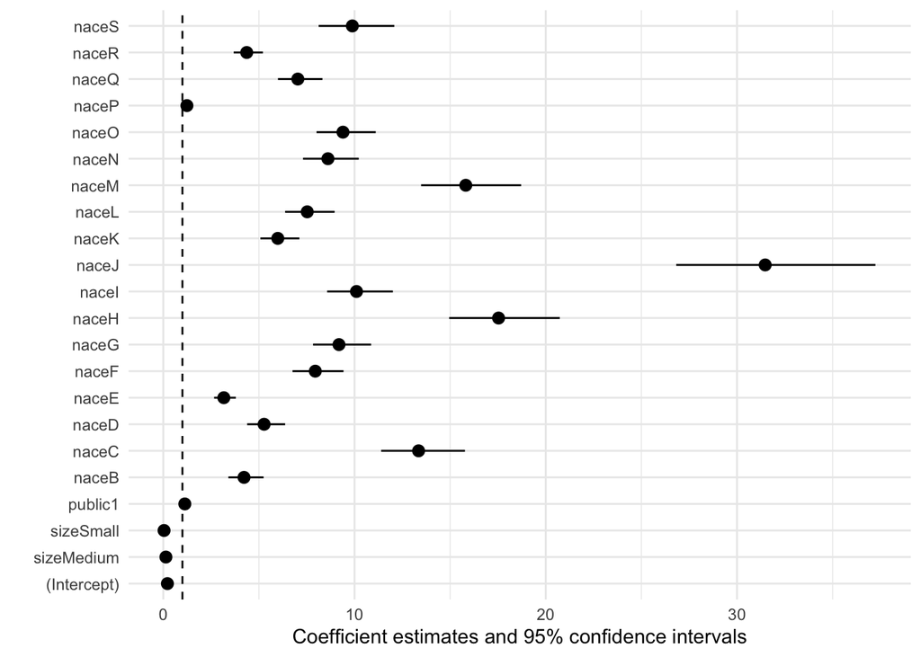

```r
modelplot(pois, exponentiate = TRUE) +
  ggplot2::geom_vline(xintercept = 1, linetype = 2)
```

**Python**

```python
pois = smf.glm("vacancies ~ C(size) + C(public) + C(nace)", data=df,
               family=sm.families.Poisson()).fit()
print(pois.summary())
```

```
                 Generalized Linear Model Regression Results
==============================================================================
Dep. Variable:              vacancies   No. Observations:                57480
Model:                            GLM   Df Residuals:                    57458
Model Family:                 Poisson   Df Model:                           21
Link Function:                    Log   Scale:                          1.0000
Method:                          IRLS   Log-Likelihood:            -1.6184e+05
Date:                Tue, 28 Apr 2026   Deviance:                   3.0177e+05
Time:                        23:25:58   Pearson chi2:                 3.12e+06
No. Iterations:                     7   Pseudo R-squ. (CS):             0.7453
Covariance Type:            nonrobust
=====================================================================================
                        coef    std err          z      P>|z|      [0.025      0.975]
-------------------------------------------------------------------------------------
Intercept            -1.5287      0.083    -18.508      0.000      -1.691      -1.367
C(size)[T.Medium]    -1.9830      0.017   -117.505      0.000      -2.016      -1.950
C(size)[T.Small]     -3.1914      0.032   -100.947      0.000      -3.253      -3.129
C(public)[T.1]        0.1193      0.015      7.901      0.000       0.090       0.149
C(nace)[T.B]          1.4404      0.110     13.096      0.000       1.225       1.656
C(nace)[T.C]          2.5915      0.083     31.254      0.000       2.429       2.754
C(nace)[T.D]          1.6624      0.095     17.447      0.000       1.476       1.849
C(nace)[T.E]          1.1527      0.090     12.744      0.000       0.975       1.330
C(nace)[T.F]          2.0730      0.085     24.439      0.000       1.907       2.239
C(nace)[T.G]          2.2179      0.083     26.569      0.000       2.054       2.381
C(nace)[T.H]          2.8640      0.083     34.335      0.000       2.701       3.028
C(nace)[T.I]          2.3129      0.086     26.898      0.000       2.144       2.481
C(nace)[T.J]          3.4491      0.084     41.242      0.000       3.285       3.613
C(nace)[T.K]          1.7898      0.086     20.803      0.000       1.621       1.958
C(nace)[T.L]          2.0186      0.087     23.272      0.000       1.849       2.189
C(nace)[T.M]          2.7611      0.084     33.036      0.000       2.597       2.925
C(nace)[T.N]          2.1529      0.085     25.196      0.000       1.985       2.320
C(nace)[T.O]          2.2404      0.083     26.897      0.000       2.077       2.404
C(nace)[T.P]          0.2120      0.085      2.484      0.013       0.045       0.379
C(nace)[T.Q]          1.9510      0.084     23.343      0.000       1.787       2.115
C(nace)[T.R]          1.4733      0.089     16.645      0.000       1.300       1.647
C(nace)[T.S]          2.2911      0.101     22.651      0.000       2.093       2.489
=====================================================================================
```

```python
np.exp(pois.params).round(3)
```

```
Intercept             0.217
C(size)[T.Medium]     0.138
C(size)[T.Small]      0.041
C(public)[T.1]        1.127
C(nace)[T.B]          4.222
C(nace)[T.C]         13.350
C(nace)[T.D]          5.272
C(nace)[T.E]          3.167
C(nace)[T.F]          7.948
C(nace)[T.G]          9.188
C(nace)[T.H]         17.532
C(nace)[T.I]         10.104
C(nace)[T.J]         31.474
C(nace)[T.K]          5.988
C(nace)[T.L]          7.528
C(nace)[T.M]         15.818
C(nace)[T.N]          8.610
C(nace)[T.O]          9.397
C(nace)[T.P]          1.236
C(nace)[T.Q]          7.036
C(nace)[T.R]          4.364
C(nace)[T.S]          9.886
dtype: float64
```

**Julia**

```julia
pois = glm(@formula(vacancies ~ size + public + nace), df, Poisson(), LogLink())
```

```
StatsModels.TableRegressionModel{GeneralizedLinearModel{GLM.GlmResp{Vector{Float64}, Poisson{Float64}, LogLink}, GLM.DensePredChol{Float64, CholeskyPivoted{Float64, Matrix{Float64}, Vector{Int64}}}}, Matrix{Float64}}

vacancies ~ 1 + size + public + nace

Coefficients:
─────────────────────────────────────────────────────────────────────────────
                  Coef.  Std. Error        z  Pr(>|z|)   Lower 95%  Upper 95%
─────────────────────────────────────────────────────────────────────────────
(Intercept)   -1.52875    0.0826013   -18.51    <1e-75  -1.69064    -1.36685
size: Medium  -1.983      0.0168757  -117.51    <1e-99  -2.01607    -1.94992
size: Small   -3.19144    0.0316148  -100.95    <1e-99  -3.25341    -3.12948
public: 1      0.119296   0.0150995     7.90    <1e-14   0.089702    0.148891
nace: B        1.44042    0.109989     13.10    <1e-38   1.22485     1.656
nace: C        2.59151    0.0829166    31.25    <1e-99   2.42899     2.75402
nace: D        1.66241    0.0952839    17.45    <1e-67   1.47566     1.84916
nace: E        1.15266    0.0904462    12.74    <1e-36   0.975387    1.32993
nace: F        2.07296    0.0848208    24.44    <1e-99   1.90672     2.23921
nace: G        2.21786    0.0834755    26.57    <1e-99   2.05425     2.38147
nace: H        2.86405    0.0834149    34.33    <1e-99   2.70056     3.02754
nace: I        2.31294    0.0859906    26.90    <1e-99   2.1444      2.48148
nace: J        3.44915    0.0836325    41.24    <1e-99   3.28523     3.61306
nace: K        1.7898     0.0860348    20.80    <1e-95   1.62117     1.95842
nace: L        2.01861    0.0867395    23.27    <1e-99   1.8486      2.18861
nace: M        2.76112    0.0835793    33.04    <1e-99   2.59731     2.92494
nace: N        2.15293    0.0854468    25.20    <1e-99   1.98546     2.3204
nace: O        2.24037    0.0832936    26.90    <1e-99   2.07711     2.40362
nace: P        0.211996   0.0853493     2.48    0.0130   0.0447146   0.379278
nace: Q        1.95099    0.0835798    23.34    <1e-99   1.78718     2.11481
nace: R        1.47329    0.0885137    16.64    <1e-61   1.29981     1.64678
nace: S        2.29114    0.10115      22.65    <1e-99   2.09289     2.48939
─────────────────────────────────────────────────────────────────────────────
```

```julia
exp.(coef(pois))
```

```
22-element Vector{Float64}:
  0.2168074301191767
  0.13765629376480226
  0.04111244050080372
  1.126703916422319
  4.222479642851705
 13.3498830155202
  5.27200794632387
  3.166599489148658
  7.94833098943999
  9.187626946851429
  ⋮
  5.988250611420384
  7.5278325124697485
 15.817600084216712
  8.610056658237669
  9.396780942599694
  1.2361430732712468
  7.0356771733337915
  4.363580939561773
  9.886236058353877
```

**Interpretation.** For example, `sizeMedium = 0.14` means that, holding `public` and `nace` fixed, the expected number of vacancies for medium-sized firms is about 14% of that for large firms (the reference). Equivalently, `(0.14 - 1) * 100 ≈ -86%`.

# 6 Detecting overdispersion

Pure Poisson assumes $\operatorname{Var}(Y\mid X) = E(Y\mid X)$. The Pearson dispersion statistic
$$\hat{\phi} = \frac{1}{n - p} \sum_{i=1}^{n} \frac{(y_i - \hat{\mu}_i)^2}{\hat{\mu}_i}$$
is close to 1 if Poisson is correct; $\hat{\phi} \gg 1$ signals overdispersion.

**R**

```r
phi <- sum(residuals(pois, type = "pearson")^2) / df.residual(pois)
round(phi, 2)
```

```
[1] 54.37
```

Cameron–Trivedi regression test:

```r
AER::dispersiontest(pois, trafo = 1)
```

```
    Overdispersion test

data:  pois
z = 3.2467, p-value = 0.0005837
alternative hypothesis: true alpha is greater than 0
sample estimates:
   alpha
53.11256
```

`performance` wraps a similar diagnostic:

```r
performance::check_overdispersion(pois)
```

```
# Overdispersion test

       dispersion ratio =      54.371
  Pearson's Chi-Squared = 3124058.614
                p-value =     < 0.001
```

**Python**

```python
mu_hat = pois.fittedvalues
pearson = (df["vacancies"] - mu_hat) / np.sqrt(mu_hat)
phi_py = float((pearson ** 2).sum() / pois.df_resid)
round(phi_py, 2)
```

```
54.37
```

**Julia**

```julia
mu_hat = predict(pois)
```

```
57480-element Vector{Float64}:
 2.295424793675055
 2.295424793675055
 2.295424793675055
 0.315979669713144
 0.315979669713144
 1.065925867492544
 1.065925867492544
 1.065925867492544
 0.14673140434705534
 0.14673140434705534
 ⋮
 0.04156700921266531
 0.3019622864733389
 0.14673140434705534
 0.00891348257090681
 0.04156700921266531
 0.14673140434705534
 0.12601951347852547
 0.12601951347852547
 0.11899394958248415
```

```julia
phi_jl = sum((df.vacancies .- mu_hat) .^ 2 ./ mu_hat) / dof_residual(pois)
```

```
54.37022249302587
```

```julia
round(phi_jl, digits = 2)
```

```
54.37
```

The dispersion statistic is far above 1. Pure-Poisson SEs are anti-conservative by roughly $\sqrt{\hat{\phi}}$.

# 7 Quasi-Poisson and Negative Binomial

Three options share the exponential mean specification but model the variance differently.

| Model | $\operatorname{Var}(Y_i)$ | Likelihood | Dispersion estimated by |
| --- | --- | --- | --- |
| Poisson | $\mu_i$ | full | – |
| Quasi-Poisson | $\phi\, \mu_i$ | quasi-MLE | Pearson statistic |
| NB1 | $\mu_i + \mu_i / k = (1 + 1/k)\, \mu_i$ | full | MLE for $k$ |
| NB2 | $\mu_i + \mu_i^2 / k$ | full | MLE for $k$ |

Quasi-Poisson and NB1 share the variance form $\operatorname{Var} = \phi\mu$ (with $\phi = 1 + 1/k$) and produce numerically similar $\hat{\boldsymbol{\beta}}$, but they are **not** the same model: the standard errors come from different assumptions.

**R**

```r
qp  <- glm(vacancies ~ size + public + nace, data = df,
           family = quasipoisson(link = "log"))
```

```r
nb2 <- MASS::glm.nb(vacancies ~ size + public + nace, data = df)
nb2$theta  # this is k in our notation
```

```
[1] 0.06027416
```

Side-by-side comparison (IRR with SE):

```r
modelsummary(list(Poisson       = pois,
                  `Quasi-Poiss` = qp,
                  NB2           = nb2),
             exponentiate = TRUE,
             statistic    = "({std.error})",
             gof_omit     = "F|RMSE")
```

|  | Poisson | Quasi-Poiss | NB2 |
| --- | --- | --- | --- |
| (Intercept) | 0.217 | 0.217 | 0.457 |
|  | (0.018) | (0.132) | (0.063) |
| sizeMedium | 0.138 | 0.138 | 0.154 |
|  | (0.002) | (0.017) | (0.007) |
| sizeSmall | 0.041 | 0.041 | 0.045 |
|  | (0.001) | (0.010) | (0.003) |
| public1 | 1.127 | 1.127 | 0.777 |
|  | (0.017) | (0.125) | (0.053) |
| naceB | 4.222 | 4.222 | 1.814 |
|  | (0.464) | (3.425) | (0.433) |
| naceC | 13.350 | 13.350 | 6.086 |
|  | (1.107) | (8.162) | (0.878) |
| naceD | 5.272 | 5.272 | 2.731 |
|  | (0.502) | (3.704) | (0.571) |
| naceE | 3.167 | 3.167 | 2.365 |
|  | (0.286) | (2.112) | (0.393) |
| naceF | 7.948 | 7.948 | 5.722 |
|  | (0.674) | (4.971) | (0.886) |
| naceG | 9.188 | 9.188 | 3.668 |
|  | (0.767) | (5.655) | (0.542) |
| naceH | 17.532 | 17.532 | 7.974 |
|  | (1.462) | (10.784) | (1.278) |
| naceI | 10.104 | 10.104 | 4.200 |
|  | (0.869) | (6.407) | (0.710) |
| naceJ | 31.474 | 31.474 | 9.749 |
|  | (2.632) | (19.409) | (1.626) |
| naceK | 5.988 | 5.988 | 3.262 |
|  | (0.515) | (3.799) | (0.544) |
| naceL | 7.528 | 7.528 | 3.000 |
|  | (0.653) | (4.815) | (0.494) |
| naceM | 15.818 | 15.818 | 5.818 |
|  | (1.322) | (9.748) | (0.930) |
| naceN | 8.610 | 8.610 | 4.467 |
|  | (0.736) | (5.425) | (0.747) |
| naceO | 9.397 | 9.397 | 6.927 |
|  | (0.783) | (5.771) | (1.081) |
| naceP | 1.236 | 1.236 | 0.990 |
|  | (0.106) | (0.778) | (0.142) |
| naceQ | 7.036 | 7.036 | 3.877 |
|  | (0.588) | (4.336) | (0.582) |
| naceR | 4.364 | 4.364 | 4.485 |
|  | (0.386) | (2.848) | (0.728) |
| naceS | 9.886 | 9.886 | 4.556 |
|  | (1.000) | (7.374) | (0.966) |
| Num.Obs. | 57480 | 57480 | 57480 |
| AIC | 323720.9 |  | 76256.0 |
| BIC | 323918.0 |  | 76462.0 |
| Log.Lik. | -161838.468 |  | -38104.977 |

**Python**

```python
nb2 = smf.negativebinomial("vacancies ~ C(size) + C(public) + C(nace)",
                           data = df).fit(disp = False)
print(nb2.summary())
```

```
                     NegativeBinomial Regression Results
==============================================================================
Dep. Variable:              vacancies   No. Observations:                57480
Model:               NegativeBinomial   Df Residuals:                    57458
Method:                           MLE   Df Model:                           21
Date:                Tue, 28 Apr 2026   Pseudo R-squ.:                     nan
Time:                        23:26:03   Log-Likelihood:                    nan
converged:                      False   LL-Null:                       -40306.
Covariance Type:            nonrobust   LLR p-value:                       nan
=====================================================================================
                        coef    std err          z      P>|z|      [0.025      0.975]
-------------------------------------------------------------------------------------
Intercept            -1.5287        nan        nan        nan         nan         nan
C(size)[T.Medium]    -1.9830        nan        nan        nan         nan         nan
C(size)[T.Small]     -3.1914        nan        nan        nan         nan         nan
C(public)[T.1]        0.1193        nan        nan        nan         nan         nan
C(nace)[T.B]          1.4404        nan        nan        nan         nan         nan
C(nace)[T.C]          2.5915        nan        nan        nan         nan         nan
C(nace)[T.D]          1.6624        nan        nan        nan         nan         nan
C(nace)[T.E]          1.1527        nan        nan        nan         nan         nan
C(nace)[T.F]          2.0730        nan        nan        nan         nan         nan
C(nace)[T.G]          2.2179        nan        nan        nan         nan         nan
C(nace)[T.H]          2.8640        nan        nan        nan         nan         nan
C(nace)[T.I]          2.3129        nan        nan        nan         nan         nan
C(nace)[T.J]          3.4491        nan        nan        nan         nan         nan
C(nace)[T.K]          1.7898        nan        nan        nan         nan         nan
C(nace)[T.L]          2.0186        nan        nan        nan         nan         nan
C(nace)[T.M]          2.7611        nan        nan        nan         nan         nan
C(nace)[T.N]          2.1529        nan        nan        nan         nan         nan
C(nace)[T.O]          2.2404        nan        nan        nan         nan         nan
C(nace)[T.P]          0.2120        nan        nan        nan         nan         nan
C(nace)[T.Q]          1.9510        nan        nan        nan         nan         nan
C(nace)[T.R]          1.4733        nan        nan        nan         nan         nan
C(nace)[T.S]          2.2911        nan        nan        nan         nan         nan
alpha                    inf        nan        nan        nan         nan         nan
=====================================================================================
```

`statsmodels` exposes quasi-Poisson via the `Poisson` family with `scale = "X2"`:

```python
qp = smf.glm("vacancies ~ C(size) + C(public) + C(nace)",
             data = df, family = sm.families.Poisson()).fit(scale = "X2")
qp.bse.head()
```

```
Intercept            0.609076
C(size)[T.Medium]    0.124437
C(size)[T.Small]     0.233119
C(public)[T.1]       0.111339
C(nace)[T.B]         0.811025
dtype: float64
```

**Julia**

```julia
nb2 = negbin(@formula(vacancies ~ size + public + nace), df, LogLink())
```

```
StatsModels.TableRegressionModel{GeneralizedLinearModel{GLM.GlmResp{Vector{Float64}, NegativeBinomial{Float64}, LogLink}, GLM.DensePredChol{Float64, CholeskyPivoted{Float64, Matrix{Float64}, Vector{Int64}}}}, Matrix{Float64}}

vacancies ~ 1 + size + public + nace

Coefficients:
───────────────────────────────────────────────────────────────────────────────
                    Coef.  Std. Error       z  Pr(>|z|)  Lower 95%    Upper 95%
───────────────────────────────────────────────────────────────────────────────
(Intercept)   -0.784517     0.25078     -3.13    0.0018  -1.27604   -0.292997
size: Medium  -1.87025      0.0852638  -21.93    <1e-99  -2.03736   -1.70313
size: Small   -3.09896      0.108831   -28.48    <1e-99  -3.31227   -2.88566
public: 1     -0.25209      0.123676    -2.04    0.0415  -0.494491  -0.00968973
nace: B        0.596683     0.436399     1.37    0.1715  -0.258643   1.45201
nace: C        1.80721      0.263727     6.85    <1e-11   1.29031    2.32411
nace: D        1.00564      0.381961     2.63    0.0085   0.257006   1.75426
nace: E        0.861355     0.303321     2.84    0.0045   0.266857   1.45585
nace: F        1.74475      0.282775     6.17    <1e-09   1.19052    2.29898
nace: G        1.30096      0.269934     4.82    <1e-05   0.7719     1.83002
nace: H        2.07759      0.292866     7.09    <1e-11   1.50359    2.6516
nace: I        1.43605      0.308996     4.65    <1e-05   0.830431   2.04167
nace: J        2.27862      0.304754     7.48    <1e-13   1.68132    2.87593
nace: K        1.18342      0.304421     3.89    0.0001   0.586763   1.78007
nace: L        1.0999       0.300738     3.66    0.0003   0.510461   1.68933
nace: M        1.76234      0.291971     6.04    <1e-08   1.19009    2.33459
nace: N        1.49758      0.305412     4.90    <1e-06   0.898981   2.09617
nace: O        1.93631      0.28529      6.79    <1e-10   1.37716    2.49547
nace: P       -0.00896175   0.262762    -0.03    0.9728  -0.523965   0.506042
nace: Q        1.35648      0.274066     4.95    <1e-06   0.819317   1.89364
nace: R        1.50115      0.296817     5.06    <1e-06   0.919398   2.0829
nace: S        1.51723      0.387247     3.92    <1e-04   0.758243   2.27622
───────────────────────────────────────────────────────────────────────────────
```

# 8 Marginal effects from a count model

Coefficients are multiplicative on the log scale. To express effects on the original (count) scale we use marginal effects.

**R**

Average Marginal Effect of `size`:

```r
avg_slopes(nb2, variables = "size")
```

```
       Contrast Estimate Std. Error     z Pr(>|z|)     S 2.5 % 97.5 %
 Medium - Large    -1.51     0.0512 -29.5   <0.001 631.2 -1.61  -1.41
 Small - Large     -1.70     0.0510 -33.4   <0.001 807.9 -1.80  -1.60

Term: size
Type: response
```

`avg_slopes` differentiates $\hat\mu_i = \exp(\mathbf{x}_i^\top\hat{\boldsymbol{\beta}})$ for each observation, then averages — the right thing to do once the link is non-identity.

Predicted vacancies for each NACE letter, holding `size = "Medium"` and `public = "0"`:

```r
predictions(nb2,
            newdata = datagrid(nace   = unique(df$nace),
                               size   = "Medium",
                               public = "0")) |>
  as.data.frame() |>
  subset(select = c("nace", "estimate", "conf.low", "conf.high"))
```

| nace | estimate | conf.low | conf.high |
| --- | --- | --- | --- |
| A | 0.0703645 | 0.0537825 | 0.0920590 |
| B | 0.1276426 | 0.0861234 | 0.1891778 |
| C | 0.4282147 | 0.3783274 | 0.4846804 |
| D | 0.1921513 | 0.1383983 | 0.2667817 |
| E | 0.1664221 | 0.1336563 | 0.2072206 |
| F | 0.4026531 | 0.3437779 | 0.4716114 |
| G | 0.2580897 | 0.2259833 | 0.2947575 |
| H | 0.5611121 | 0.4649525 | 0.6771591 |
| I | 0.2955026 | 0.2393801 | 0.3647830 |
| J | 0.6859687 | 0.5578413 | 0.8435249 |
| K | 0.2295454 | 0.1867620 | 0.2821297 |
| L | 0.2111253 | 0.1725183 | 0.2583721 |
| M | 0.4093760 | 0.3389726 | 0.4944020 |
| N | 0.3143098 | 0.2552843 | 0.3869830 |
| O | 0.4874098 | 0.3962485 | 0.5995438 |
| P | 0.0696816 | 0.0593549 | 0.0818049 |
| Q | 0.2728375 | 0.2293844 | 0.3245221 |
| R | 0.3155717 | 0.2537461 | 0.3924613 |
| S | 0.3206040 | 0.2313381 | 0.4443147 |

**Python**

```python
from marginaleffects import avg_slopes
avg_slopes(pois, variables = "size").to_pandas()
```

[output not shown]

**Julia**

`Effects.jl` works with `GLM.jl` models; for a Poisson model it returns predictions on the response scale.

```julia
using Effects
effects(Dict(:size => ["Large", "Medium", "Small"]), pois)
```

[output not shown]

# 9 Exercises

## 9.1 Exercise 1 — Poisson vs. NB on a sub-sample

Restrict the data to firms in NACE letter `C` (manufacturing). Refit the Poisson and NB2 models. Does the NB shape parameter $k$ become smaller or larger compared to the full-sample fit? What does that say about the dispersion of vacancies in this sector?

## 9.2 Exercise 2 — OLS vs. Poisson predictions

For each combination of `size` and `public`, compute (i) the OLS-fitted mean from the model in *Why not OLS?*, and (ii) the Poisson-fitted mean from *Poisson regression*. Plot both against the empirical group means. Where do they disagree the most?

## 9.3 Exercise 3 — Robust SEs for Poisson

Use the `sandwich` package to compute heteroskedasticity-robust SEs for the Poisson model. Compare the resulting CIs with the quasi-Poisson and NB2 CIs. Which intervals are widest? Narrowest?

# 10 Further reading

- **Theory.** Cameron, A. C., & Trivedi, P. K. (2013). *Regression Analysis of Count Data* (2nd ed.). Cambridge University Press.
- **Why not log-transform.** O’Hara, R. B., & Kotze, D. J. (2010). Do not log-transform count data. *Methods in Ecology and Evolution*, 1(2), 118–122.
- **Logs with zeros.** Bellégo, C., Benatia, D., & Pape, L.-D. (2022). Dealing with logs and zeros in regression models. arXiv:2203.11820. Chen, J., & Roth, J. (2024). Logs with zeros? Some problems and solutions. *Quarterly Journal of Economics*, 139(2), 891–936.
- **Quasi-likelihood for counts.** Wooldridge, J. M. (1999). Distribution-free estimation of some nonlinear panel data models. *Journal of Econometrics*, 90(1), 77–97.
- **Diagnostics packages.** `DHARMa` (simulated residuals), `countreg` / `topmodels` (rootograms), `performance` (assumption checks).

# 11 Script files

The code for this document can be found here:

- 09-glm-count.py
- 09-glm-count.sh
- 09-glm-count.R
- 09-glm-count.jl